# All gBlock data

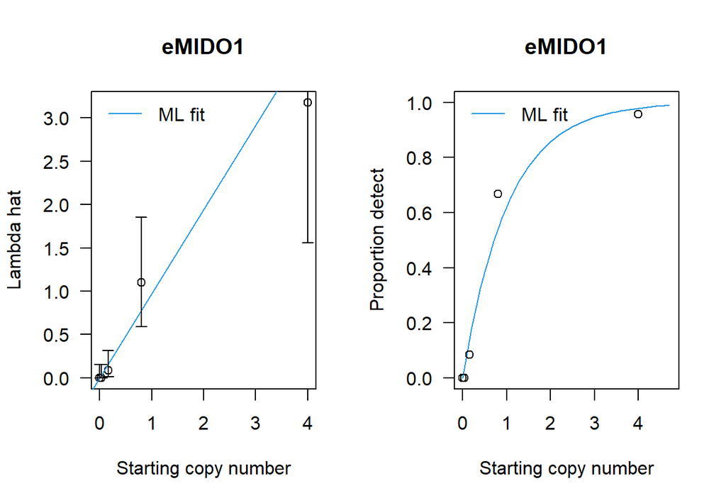

```
##
##
##
##
##  eMIDO1
## Convergence= 0
##      Estimate Std.Err Z value Pr(>z)
## beta    0.973   0.196    4.96  7e-07 ***
## ---
## Signif. codes:  0 '***' 0.001 '**' 0.01 '*' 0.05 '.' 0.1 ' ' 1
## LLR test stat= 4.310673 , df=  4 , p-value= 0.3655905
```

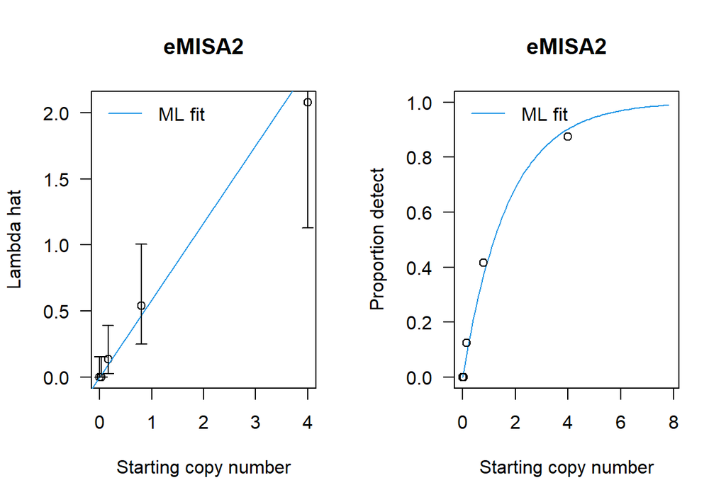

```
##
##
##
##
##  eMISA2
## Convergence= 0
##      Estimate Std.Err Z value  Pr(>z)
## beta    0.584   0.114    5.14 2.8e-07 ***
## ---
## Signif. codes:  0 '***' 0.001 '**' 0.01 '*' 0.05 '.' 0.1 ' ' 1
## LLR test stat= 1.631095 , df=  4 , p-value= 0.8031928
```

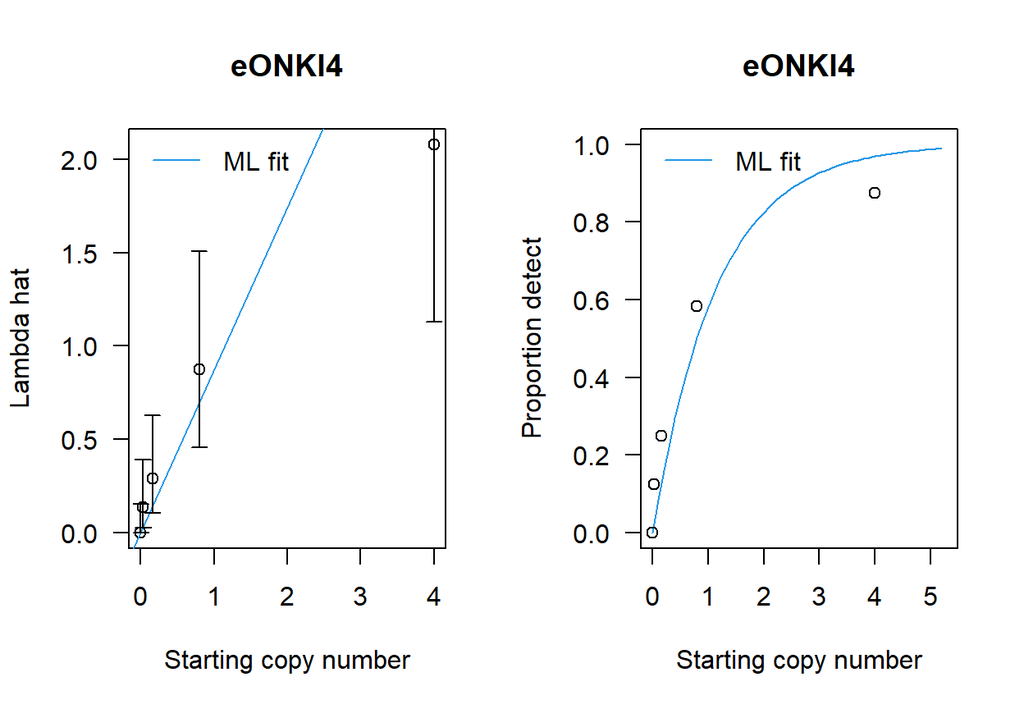

```
##
##
##
##
##  eONKI4
## Convergence= 0
##      Estimate Std.Err Z value  Pr(>z)
## beta    0.872   0.157    5.54 2.9e-08 ***
## ---
## Signif. codes:  0 '***' 0.001 '**' 0.01 '*' 0.05 '.' 0.1 ' ' 1
## LLR test stat= 11.91839 , df=  4 , p-value= 0.01796854
```

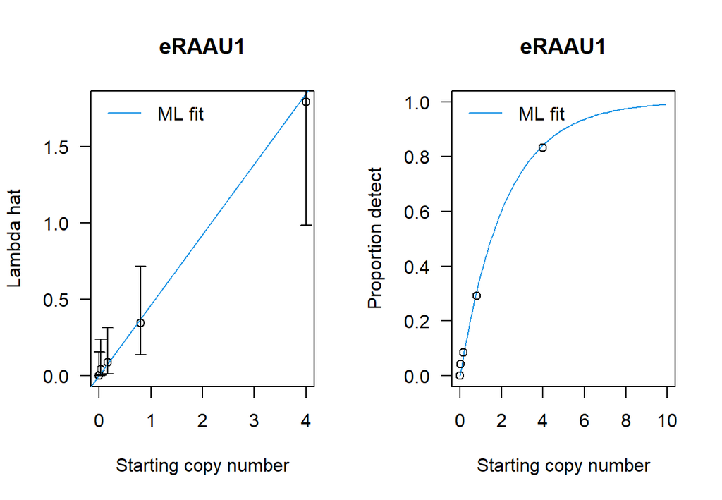

```
##
##
##
##
##  eRAAU1
## Convergence= 0
##      Estimate Std.Err Z value  Pr(>z)
## beta   0.4616  0.0921    5.01 5.5e-07 ***
## ---
## Signif. codes:  0 '***' 0.001 '**' 0.01 '*' 0.05 '.' 0.1 ' ' 1
## LLR test stat= 0.9086316 , df=  4 , p-value= 0.9233192
```

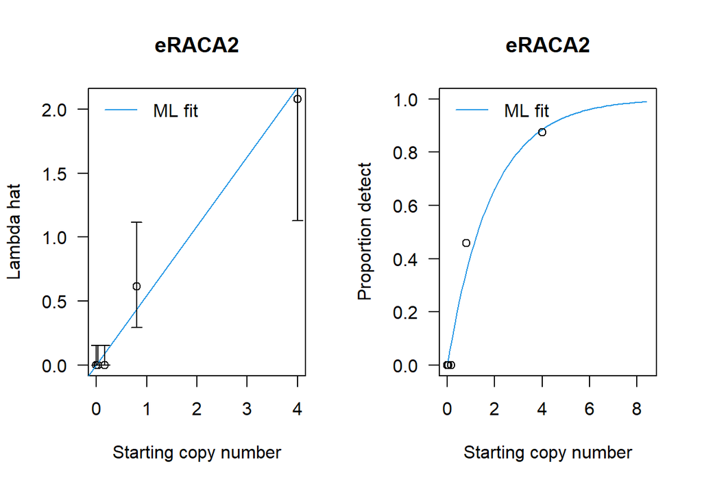

```
##
##
##
##
##  eRACA2
## Convergence= 0
##      Estimate Std.Err Z value  Pr(>z)
## beta    0.543   0.108    5.02 5.1e-07 ***
## ---
## Signif. codes:  0 '***' 0.001 '**' 0.01 '*' 0.05 '.' 0.1 ' ' 1
## LLR test stat= 6.171783 , df=  4 , p-value= 0.1866815
```

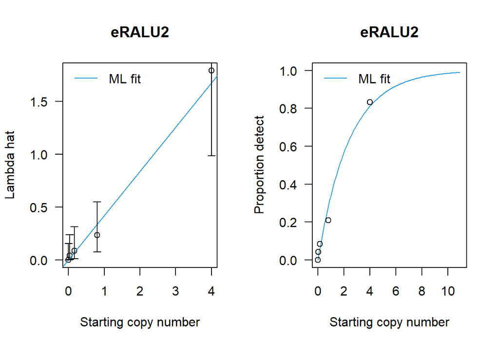

```
##
##
##
##
##  eRALU2
## Convergence= 0
##      Estimate Std.Err Z value Pr(>z)
## beta   0.4189  0.0858    4.89  1e-06 ***
## ---
## Signif. codes:  0 '***' 0.001 '**' 0.01 '*' 0.05 '.' 0.1 ' ' 1
## LLR test stat= 1.866509 , df=  4 , p-value= 0.7602944
```

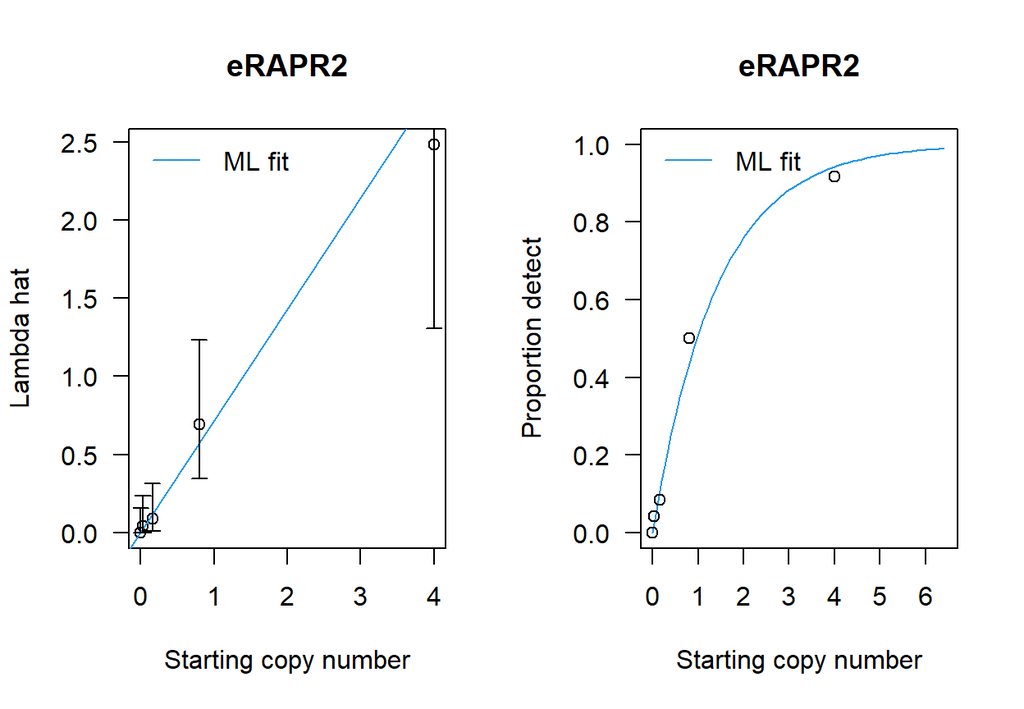

```
##
##
##
##
##  eRAPR2
## Convergence= 0
##      Estimate Std.Err Z value  Pr(>z)
## beta    0.714   0.139    5.13 2.9e-07 ***
## ---
## Signif. codes:  0 '***' 0.001 '**' 0.01 '*' 0.05 '.' 0.1 ' ' 1
## LLR test stat= 1.148873 , df=  4 , p-value= 0.8864424
```

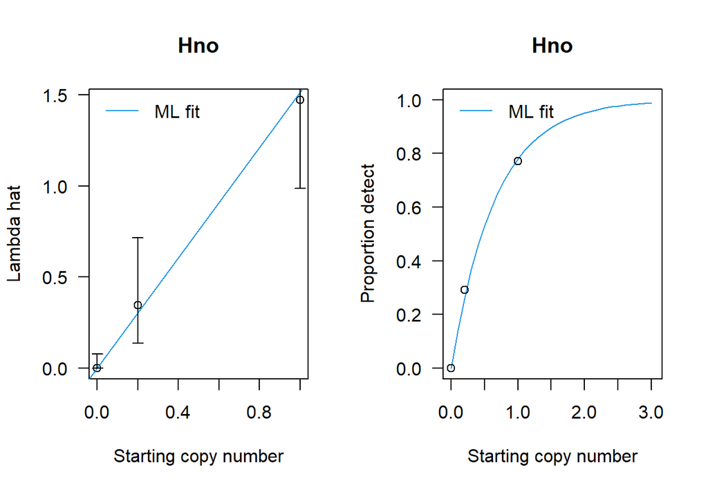

```
##
##
##
##
##  Hno
## Convergence= 0
##      Estimate Std.Err Z value  Pr(>z)
## beta    1.514   0.247    6.13 8.6e-10 ***
## ---
## Signif. codes:  0 '***' 0.001 '**' 0.01 '*' 0.05 '.' 0.1 ' ' 1
## LLR test stat= 0.1354573 , df=  2 , p-value= 0.934514
```

# 6 Estimate predicted Sq given number detects and technical replicates - no intercept (not shown)

The estimated SQ is easily obtained for given new values of nn0=number of replicates, nd0=number detected and the estimated slope betaS as: Shat <- -(log((nn0 - nd0)/nn0)) / betaS[1] The standard errors are obtained from the Hessian matrix (or via the function CalibS0Or.ddLLik()) .

# 7 Estimate Poisson models - intercept model

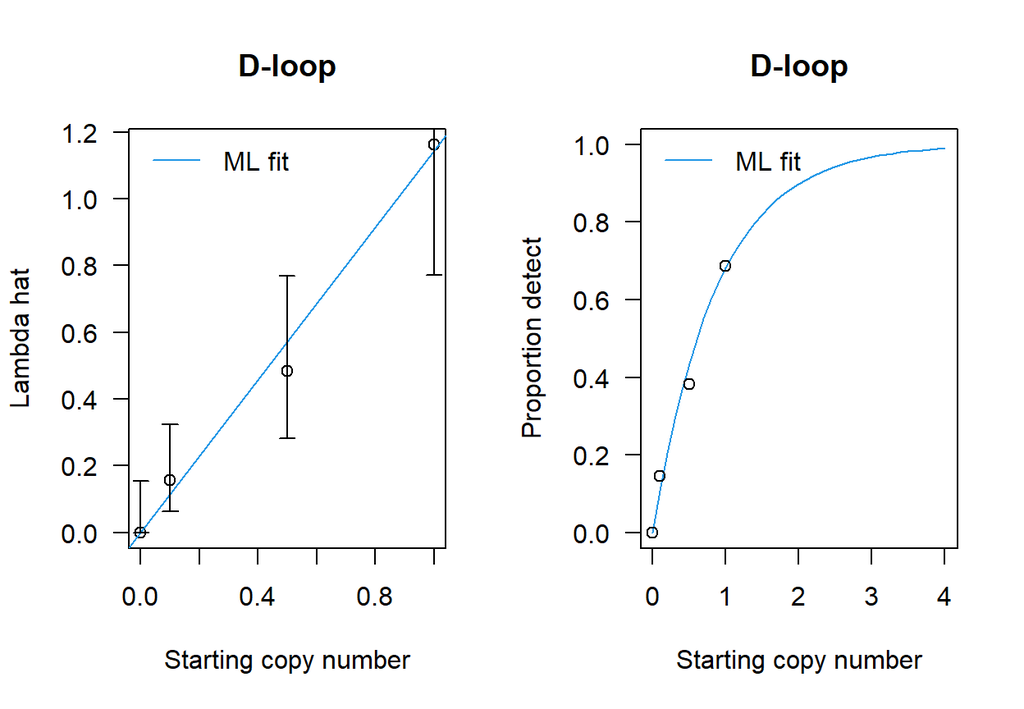

```
##
##
##
##
##  D-loop
## Convergence= 0
##       Estimate  Std.Err Z value Pr(>z)
## alpha 3.33e-09 5.31e-02    0.00      1
## beta  1.15e+00 2.04e-01    5.61  2e-08 ***
## ---
## Signif. codes:  0 '***' 0.001 '**' 0.01 '*' 0.05 '.' 0.1 ' ' 1
## LLR test stat= 1.192445 , df=  2 , p-value= 0.5508887
```

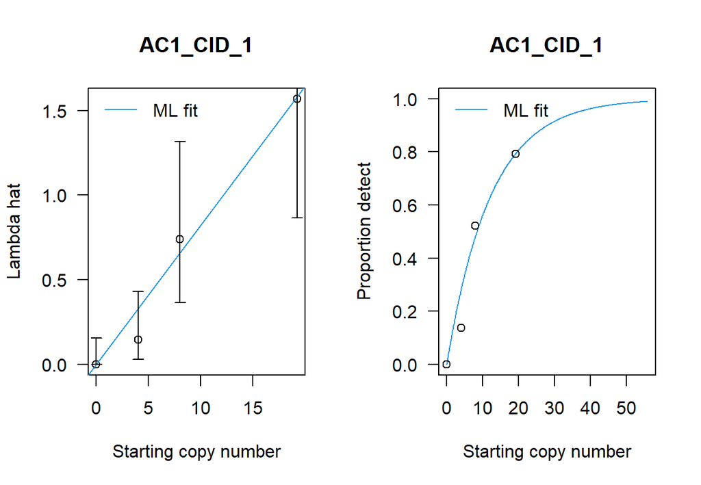

```
##
##
##
##
##  AC1_CID_1
## Convergence= 0
##       Estimate  Std.Err Z value Pr(>z)
## alpha 1.96e-08 2.49e-01    0.00 1.0000
## beta  8.23e-02 2.90e-02    2.84 0.0045 **
## ---
## Signif. codes:  0 '***' 0.001 '**' 0.01 '*' 0.05 '.' 0.1 ' ' 1
## LLR test stat= 2.757685 , df=  2 , p-value= 0.2518699
##
## Too few values for  CID
```

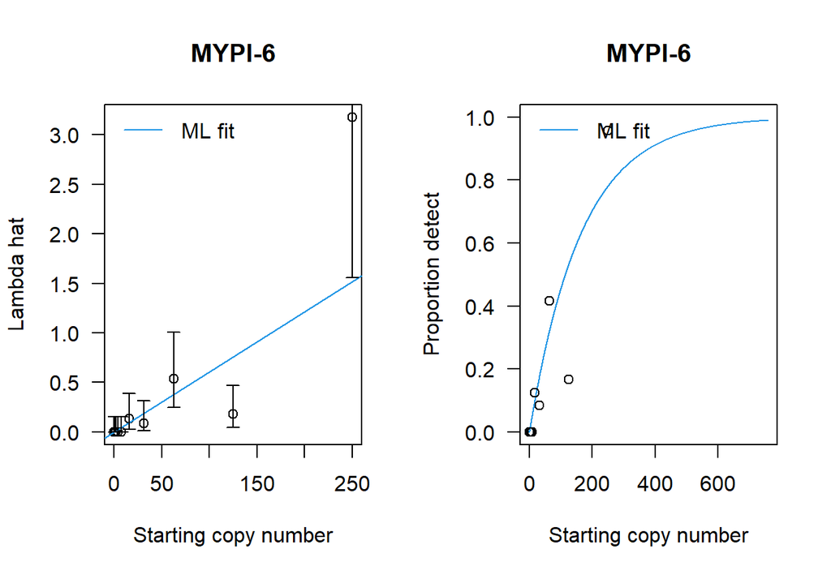

```
##
##
##
##
##  MYPI-6
## Convergence= 0
##       Estimate  Std.Err Z value  Pr(>z)
## alpha 2.78e-11 6.00e-02    0.00       1
## beta  6.07e-03 1.27e-03    4.78 1.7e-06 ***
## ---
## Signif. codes:  0 '***' 0.001 '**' 0.01 '*' 0.05 '.' 0.1 ' ' 1
## LLR test stat= 27.35988 , df=  10 , p-value= 0.002283695
```

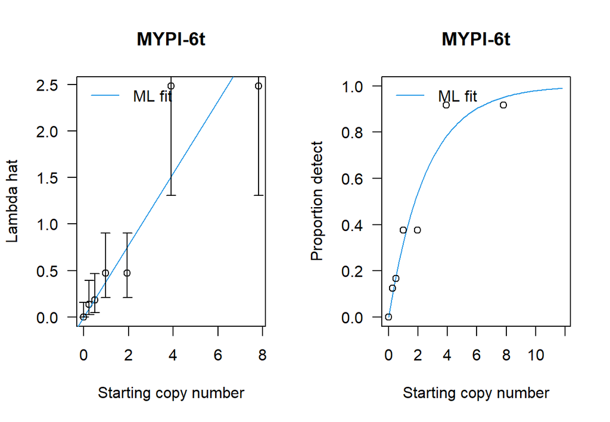

```
##
##
##
##
##  MYPI-6t
## Convergence= 0
##       Estimate  Std.Err Z value  Pr(>z)
## alpha 1.86e-08 5.46e-02    0.00       1
## beta  3.87e-01 6.69e-02    5.79 7.1e-09 ***
## ---
## Signif. codes:  0 '***' 0.001 '**' 0.01 '*' 0.05 '.' 0.1 ' ' 1
## LLR test stat= 6.803394 , df=  5 , p-value= 0.2356775
##
## Too few values for  NZMS
## Too few values for  SAFO
## Too few values for  Elod-2-NU
## Too few values for  MYPI
```

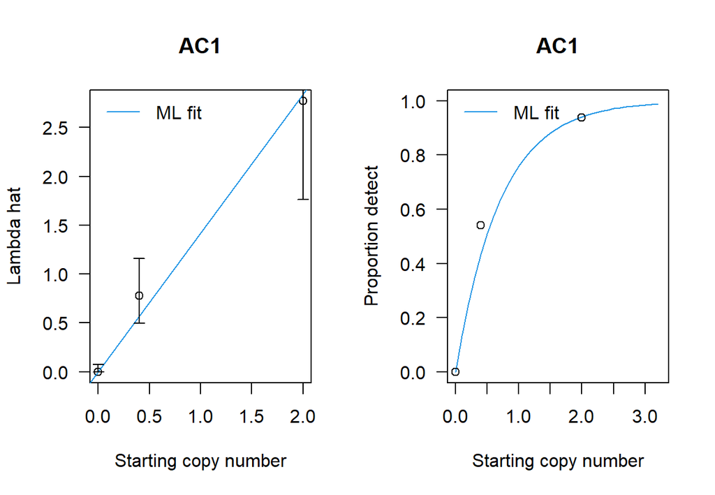

```
##
##
##
##
##  AC1
## Convergence= 0
##       Estimate  Std.Err Z value  Pr(>z)
## alpha 5.57e-10 2.02e-01    0.00 1.00000
## beta  1.42e+00 3.69e-01    3.84 0.00012 ***
## ---
## Signif. codes:  0 '***' 0.001 '**' 0.01 '*' 0.05 '.' 0.1 ' ' 1
## LLR test stat= 2.288843 , df=  1 , p-value= 0.1303071
```

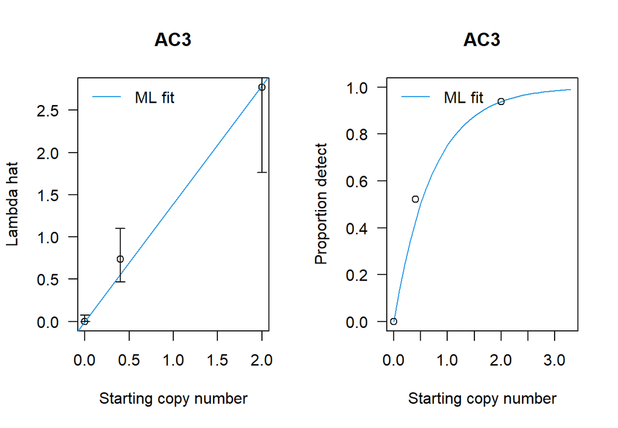

```
##
##
##
##
##  AC3
## Convergence= 0
##       Estimate  Std.Err Z value  Pr(>z)
## alpha 1.83e-08 2.00e-01    0.00 1.00000
## beta  1.39e+00 3.60e-01    3.88 0.00011 ***
## ---
## Signif. codes:  0 '***' 0.001 '**' 0.01 '*' 0.05 '.' 0.1 ' ' 1
## LLR test stat= 1.685805 , df=  1 , p-value= 0.1941549
```

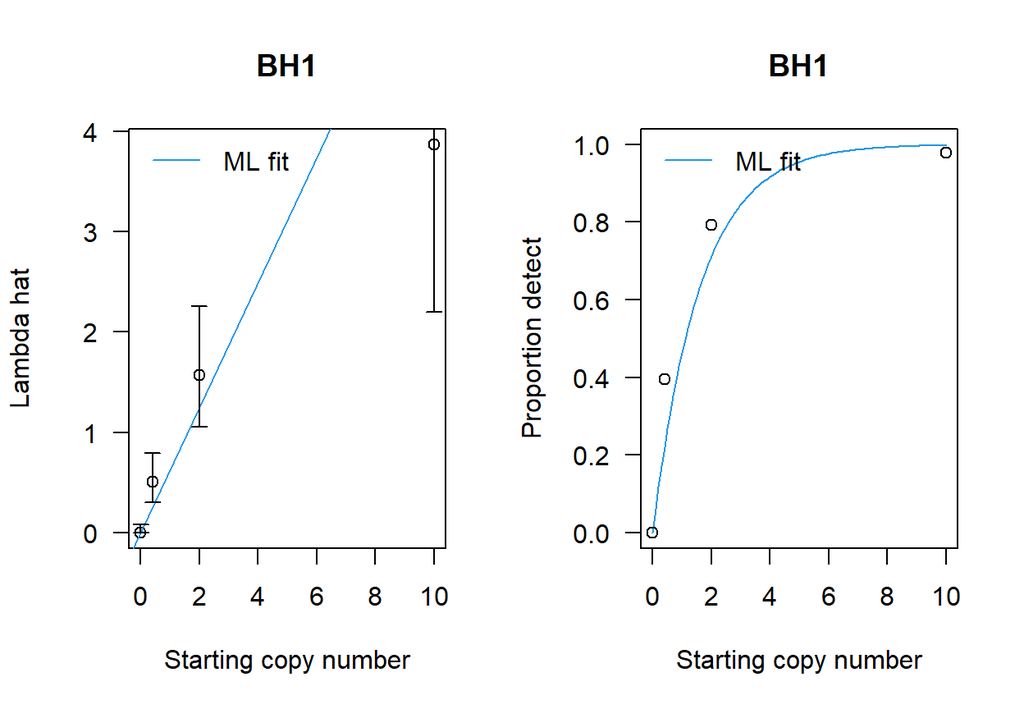

```
##
##
##
##
##  BH1
## Convergence= 0
##       Estimate  Std.Err Z value  Pr(>z)
## alpha 9.77e-09 8.58e-02    0.00       1
## beta  6.22e-01 1.29e-01    4.82 1.4e-06 ***
## ---
## Signif. codes:  0 '***' 0.001 '**' 0.01 '*' 0.05 '.' 0.1 ' ' 1
## LLR test stat= 11.96976 , df=  2 , p-value= 0.002516509
```

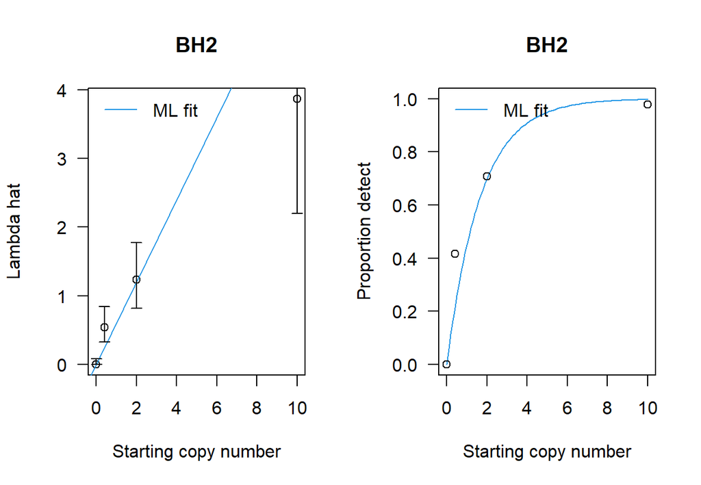

```
##
##
##
##
##  BH2
## Convergence= 0
##       Estimate  Std.Err Z value  Pr(>z)
## alpha 7.41e-09 8.18e-02     0.0       1
## beta  5.99e-01 1.27e-01     4.7 2.6e-06 ***
## ---
## Signif. codes:  0 '***' 0.001 '**' 0.01 '*' 0.05 '.' 0.1 ' ' 1
## LLR test stat= 12.58791 , df=  2 , p-value= 0.001847435
```

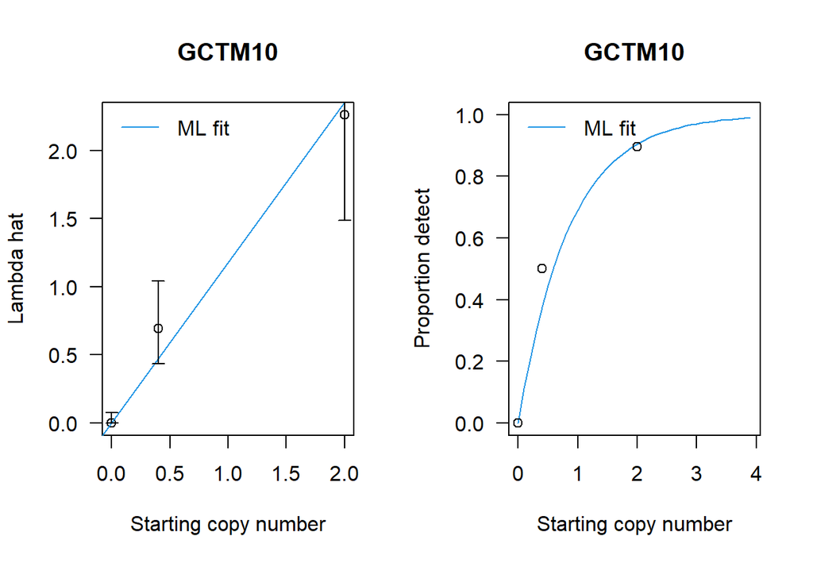

```
##
##
##
##
##  GCTM10
## Convergence= 0
##       Estimate  Std.Err Z value Pr(>z)
## alpha 3.46e-09 1.65e-01    0.00      1
## beta  1.18e+00 2.86e-01    4.11  4e-05 ***
## ---
## Signif. codes:  0 '***' 0.001 '**' 0.01 '*' 0.05 '.' 0.1 ' ' 1
## LLR test stat= 3.116952 , df=  1 , p-value= 0.07748159
```

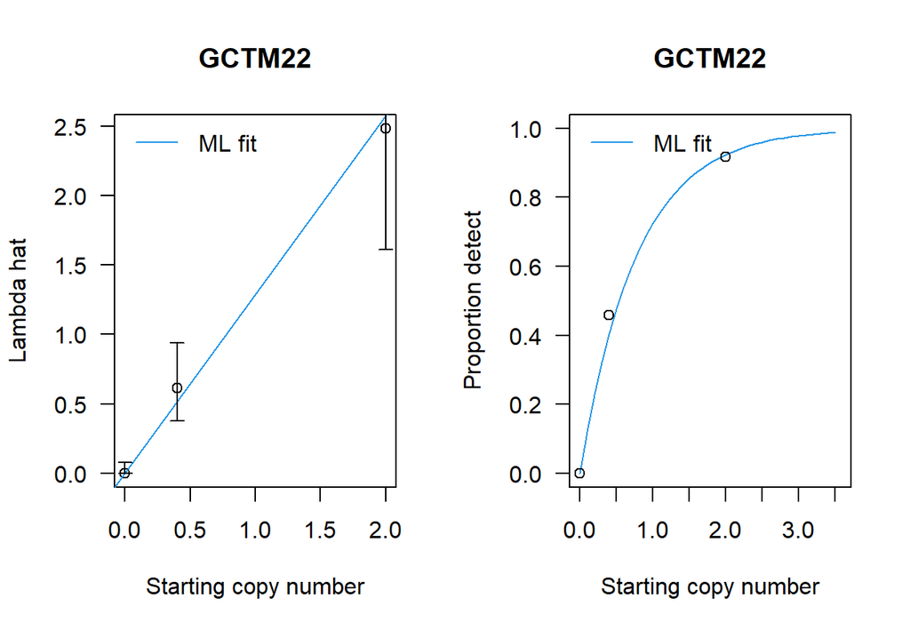

```
##
##
##
##
##  GCTM22
## Convergence= 0
##       Estimate  Std.Err Z value  Pr(>z)
## alpha 1.38e-08 1.88e-01    0.00       1
## beta  1.29e+00 3.23e-01    3.99 6.7e-05 ***
## ---
## Signif. codes:  0 '***' 0.001 '**' 0.01 '*' 0.05 '.' 0.1 ' ' 1
## LLR test stat= 0.6489803 , df=  1 , p-value= 0.4204775
```

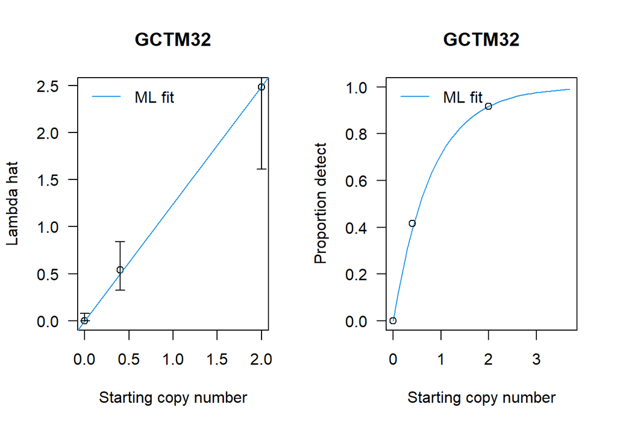

```
##
##
##
##
##  GCTM32
## Convergence= 0
##       Estimate  Std.Err Z value  Pr(>z)
## alpha 1.91e-09 1.85e-01    0.00       1
## beta  1.24e+00 3.08e-01    4.04 5.3e-05 ***
## ---
## Signif. codes:  0 '***' 0.001 '**' 0.01 '*' 0.05 '.' 0.1 ' ' 1
## LLR test stat= 0.1206682 , df=  1 , p-value= 0.7283109
##
## Too few values for  Goby
```

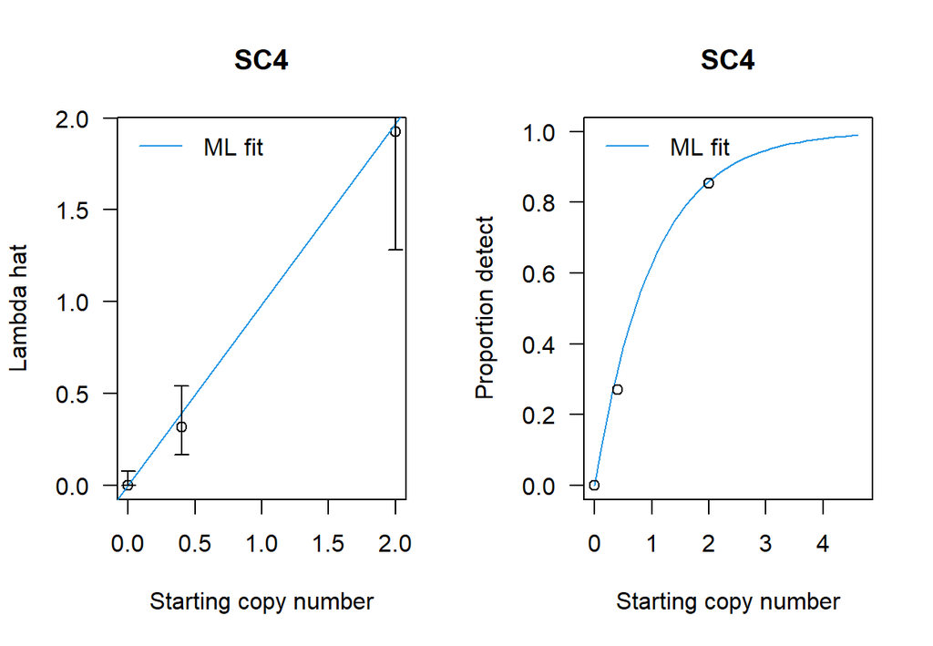

```
##
##
##
##
##  SC4
## Convergence= 0
##       Estimate  Std.Err Z value  Pr(>z)
## alpha 2.54e-10 1.64e-01    0.00       1
## beta  9.84e-01 2.35e-01    4.19 2.8e-05 ***
## ---
## Signif. codes:  0 '***' 0.001 '**' 0.01 '*' 0.05 '.' 0.1 ' ' 1
## LLR test stat= 0.6901617 , df=  1 , p-value= 0.4061094
```

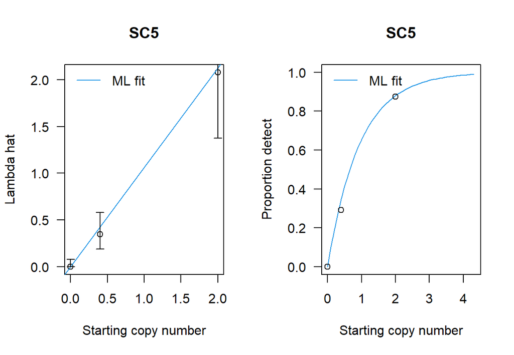

```
##
##
##
##
##  SC5
## Convergence= 0
##       Estimate  Std.Err Z value  Pr(>z)
## alpha 1.46e-09 1.73e-01    0.00       1
## beta  1.06e+00 2.56e-01    4.15 3.3e-05 ***
## ---
## Signif. codes:  0 '***' 0.001 '**' 0.01 '*' 0.05 '.' 0.1 ' ' 1
## LLR test stat= 0.6602861 , df=  1 , p-value= 0.416459
```

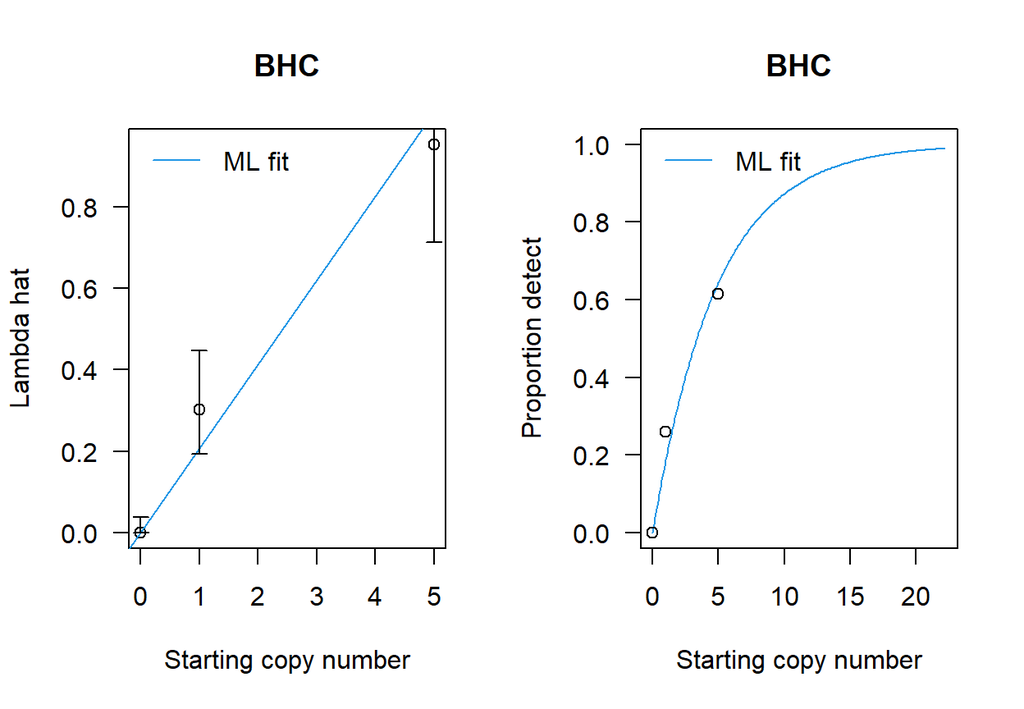

```
##
##
##
##
##  BHC
## Convergence= 0
##       Estimate  Std.Err Z value  Pr(>z)
## alpha 6.31e-09 6.26e-02    0.00       1
## beta  2.07e-01 3.66e-02    5.64 1.7e-08 ***
## ---
## Signif. codes:  0 '***' 0.001 '**' 0.01 '*' 0.05 '.' 0.1 ' ' 1
## LLR test stat= 3.509393 , df=  1 , p-value= 0.06102183
```

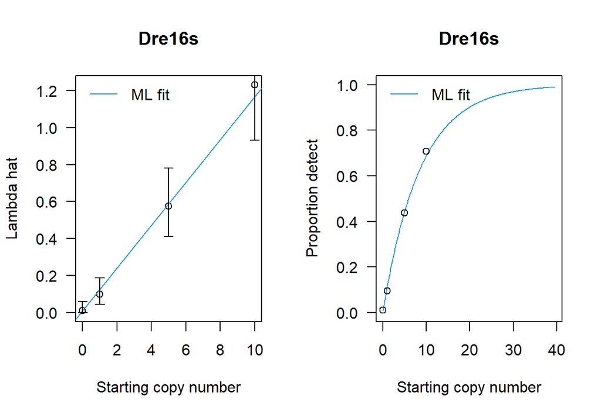

```
##
##
##
##
##  Dre16s
## Convergence= 0
##       Estimate Std.Err Z value Pr(>z)
## alpha  0.00880 0.00861    1.02   0.31
## beta   0.11590 0.01133   10.23 <2e-16 ***
## ---
## Signif. codes:  0 '***' 0.001 '**' 0.01 '*' 0.05 '.' 0.1 ' ' 1
## LLR test stat= 0.7640605 , df=  2 , p-value= 0.6824744
##
## Too few values for  SS
```

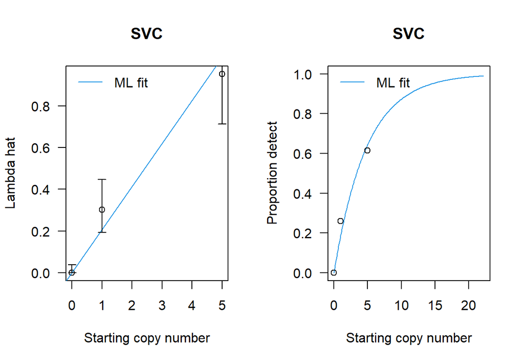

```
##
##
##
##
##  SVC
## Convergence= 0
##       Estimate  Std.Err Z value  Pr(>z)
## alpha 6.31e-09 6.26e-02    0.00       1
## beta  2.07e-01 3.66e-02    5.64 1.7e-08 ***
## ---
## Signif. codes:  0 '***' 0.001 '**' 0.01 '*' 0.05 '.' 0.1 ' ' 1
## LLR test stat= 3.509393 , df=  1 , p-value= 0.06102183
```

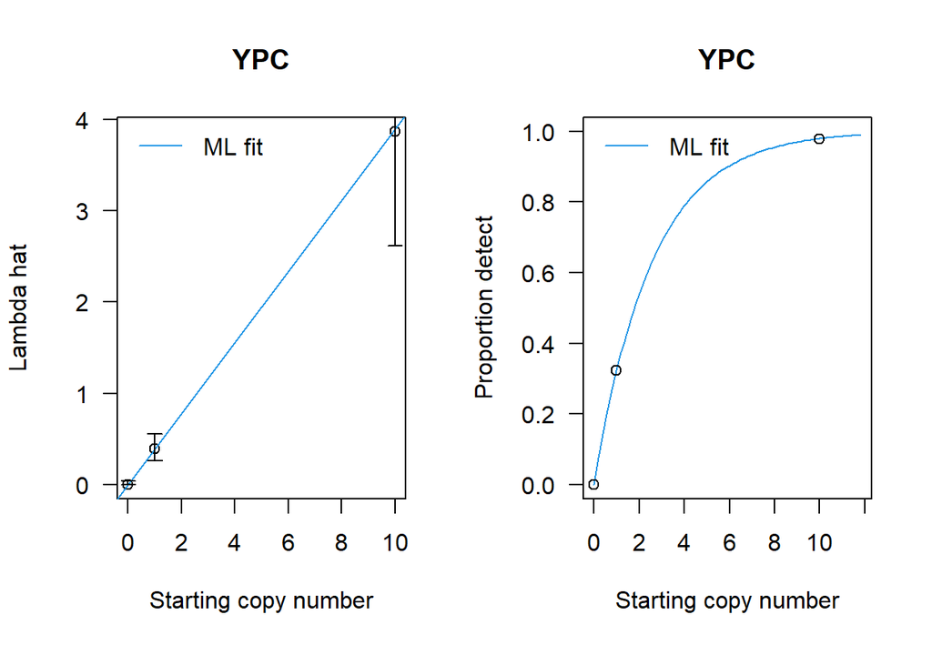

```
##
##
##
##
##  YPC
## Convergence= 0
##       Estimate  Std.Err Z value  Pr(>z)
## alpha 4.99e-09 1.11e-01    0.00       1
## beta  3.89e-01 7.91e-02    4.92 8.5e-07 ***
## ---
## Signif. codes:  0 '***' 0.001 '**' 0.01 '*' 0.05 '.' 0.1 ' ' 1
## LLR test stat= 0.001161691 , df=  1 , p-value= 0.9728105
```

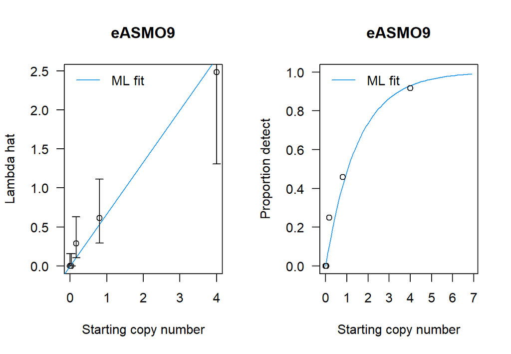

```
##
##
##
##
##  eASMO9
## Convergence= 0
##       Estimate  Std.Err Z value  Pr(>z)
## alpha 2.90e-09 5.40e-02    0.00       1
## beta  6.66e-01 1.58e-01    4.21 2.6e-05 ***
## ---
## Signif. codes:  0 '***' 0.001 '**' 0.01 '*' 0.05 '.' 0.1 ' ' 1
## LLR test stat= 5.634289 , df=  3 , p-value= 0.1308237
```

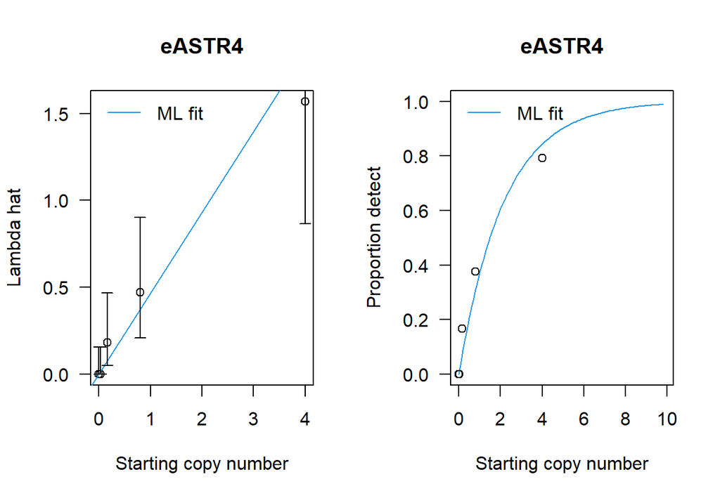

```
##
##
##
##
##  eASTR4
## Convergence= 0
##       Estimate  Std.Err Z value  Pr(>z)
## alpha 2.64e-09 4.38e-02    0.00       1
## beta  4.66e-01 1.10e-01    4.25 2.2e-05 ***
## ---
## Signif. codes:  0 '***' 0.001 '**' 0.01 '*' 0.05 '.' 0.1 ' ' 1
## LLR test stat= 4.058386 , df=  3 , p-value= 0.2552281
```

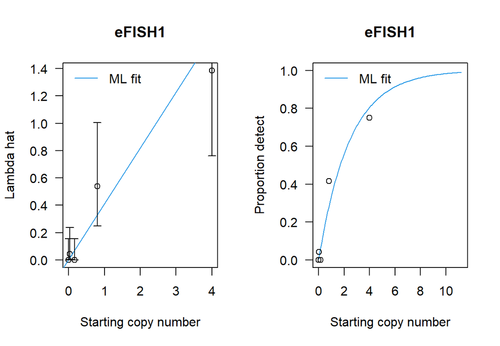

```
##
##
##
##
##  eFISH1
## Convergence= 0
##       Estimate Std.Err Z value  Pr(>z)
## alpha  0.00316 0.01669    0.19    0.85
## beta   0.40873 0.08563    4.77 1.8e-06 ***
## ---
## Signif. codes:  0 '***' 0.001 '**' 0.01 '*' 0.05 '.' 0.1 ' ' 1
## LLR test stat= 6.595206 , df=  3 , p-value= 0.08598249
```

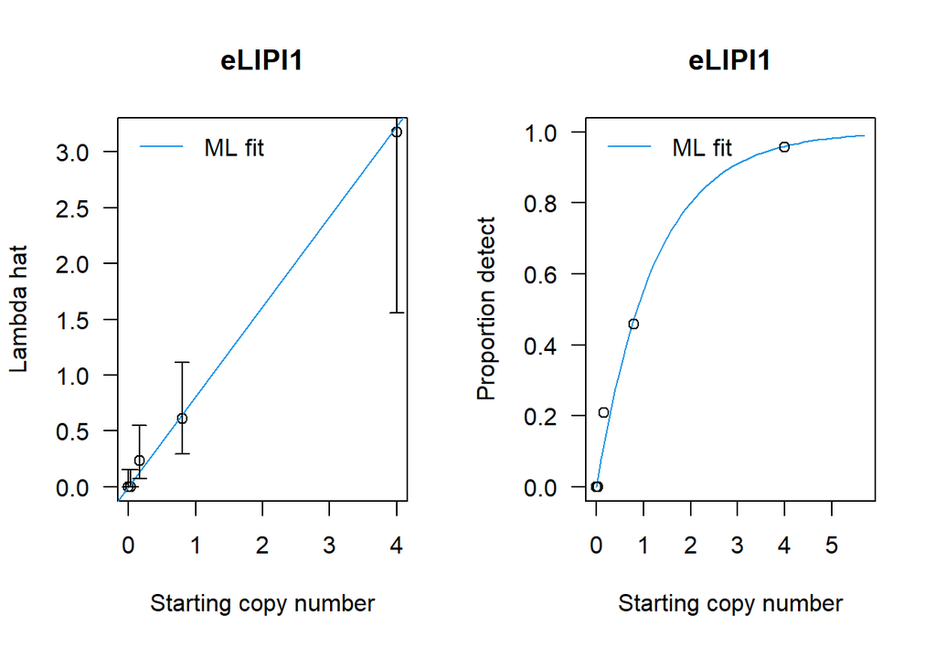

```
##
##
##
##
##  eLIPI1
## Convergence= 0
##       Estimate  Std.Err Z value  Pr(>z)
## alpha 1.03e-09 7.17e-02    0.00       1
## beta  8.08e-01 2.05e-01    3.93 8.4e-05 ***
## ---
## Signif. codes:  0 '***' 0.001 '**' 0.01 '*' 0.05 '.' 0.1 ' ' 1
## LLR test stat= 2.721685 , df=  3 , p-value= 0.4365547
```

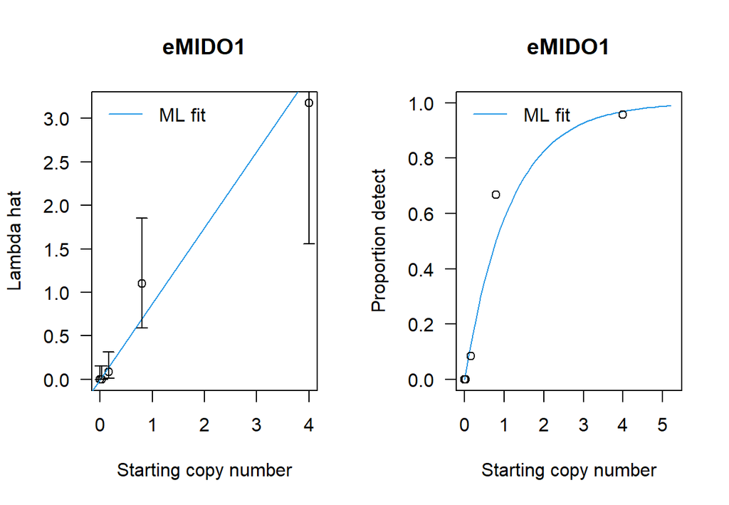

```
##
##
##
##
##  eMIDO1
## Convergence= 0
##       Estimate  Std.Err Z value  Pr(>z)
## alpha 5.97e-10 1.14e-01     0.0       1
## beta  8.74e-01 2.24e-01     3.9 9.7e-05 ***
## ---
## Signif. codes:  0 '***' 0.001 '**' 0.01 '*' 0.05 '.' 0.1 ' ' 1
## LLR test stat= 4.59117 , df=  3 , p-value= 0.2043009
```

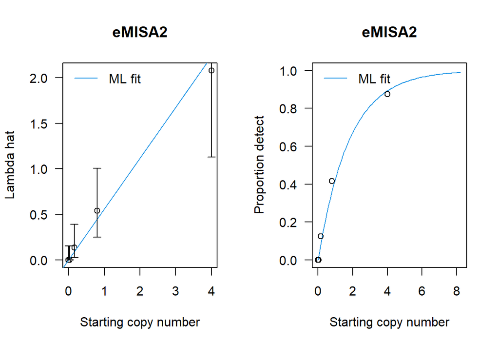

```
##
##
##
##
##  eMISA2
## Convergence= 0
##       Estimate  Std.Err Z value  Pr(>z)
## alpha 5.64e-10 5.92e-02    0.00       1
## beta  5.59e-01 1.32e-01    4.24 2.3e-05 ***
## ---
## Signif. codes:  0 '***' 0.001 '**' 0.01 '*' 0.05 '.' 0.1 ' ' 1
## LLR test stat= 1.682044 , df=  3 , p-value= 0.6409331
```

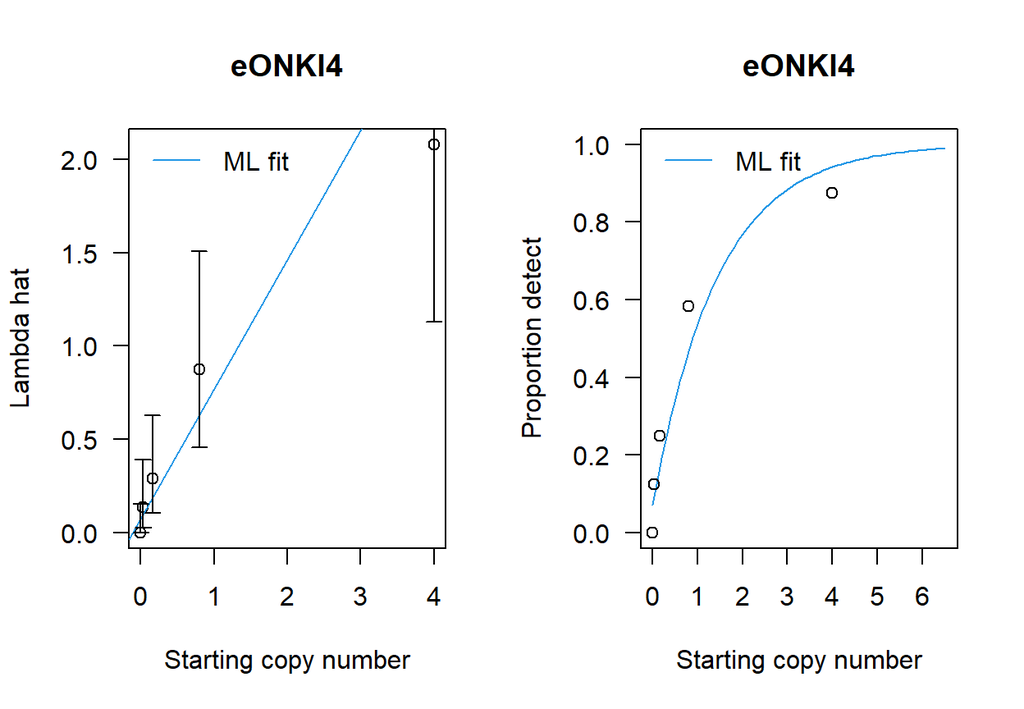

```
##
##
##
##
##  eONKI4
## Convergence= 0
##       Estimate Std.Err Z value  Pr(>z)
## alpha   0.0749  0.0486    1.54    0.12
## beta    0.6939  0.1601    4.33 1.5e-05 ***
## ---
## Signif. codes:  0 '***' 0.001 '**' 0.01 '*' 0.05 '.' 0.1 ' ' 1
## LLR test stat= 7.671079 , df=  3 , p-value= 0.05332185
```

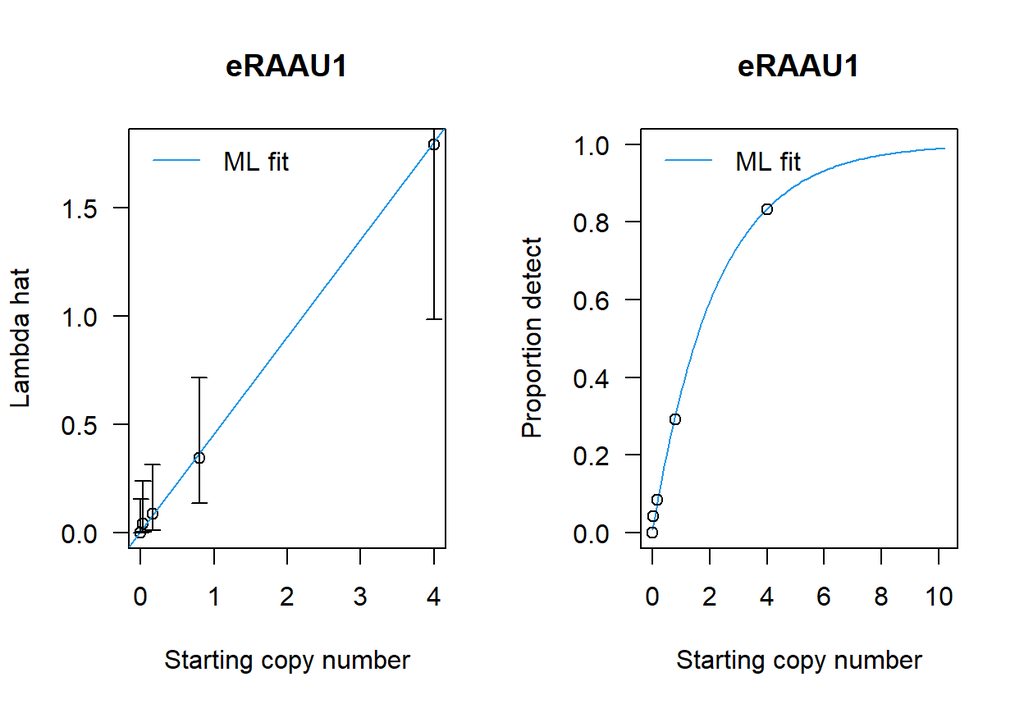

```
##
##
##
##
##  eRAAU1
## Convergence= 0
##       Estimate Std.Err Z value  Pr(>z)
## alpha  0.00722 0.02104    0.34    0.73
## beta   0.44846 0.09693    4.63 3.7e-06 ***
## ---
## Signif. codes:  0 '***' 0.001 '**' 0.01 '*' 0.05 '.' 0.1 ' ' 1
## LLR test stat= 0.7629684 , df=  3 , p-value= 0.8583024
```

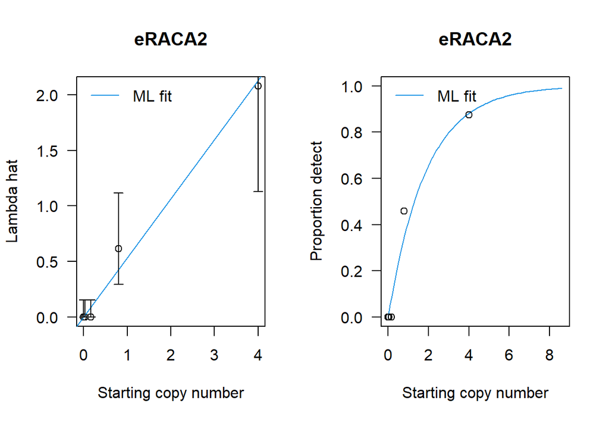

```
##
##
##
##
##  eRACA2
## Convergence= 0
##       Estimate  Std.Err Z value Pr(>z)
## alpha 5.92e-09 2.14e-01    0.00 1.0000
## beta  5.33e-01 1.79e-01    2.98 0.0029 **
## ---
## Signif. codes:  0 '***' 0.001 '**' 0.01 '*' 0.05 '.' 0.1 ' ' 1
## LLR test stat= 6.180137 , df=  3 , p-value= 0.1031676
```

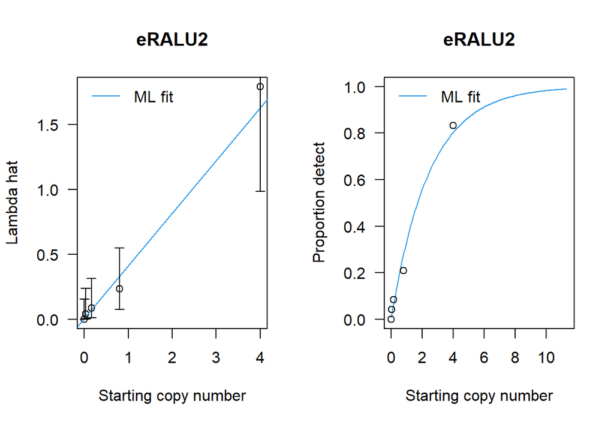

```
##
##
##
##
##  eRALU2
## Convergence= 0
##       Estimate Std.Err Z value  Pr(>z)
## alpha  0.00771 0.02002    0.39     0.7
## beta   0.40536 0.08975    4.52 6.3e-06 ***
## ---
## Signif. codes:  0 '***' 0.001 '**' 0.01 '*' 0.05 '.' 0.1 ' ' 1
## LLR test stat= 1.677365 , df=  3 , p-value= 0.6419778
```

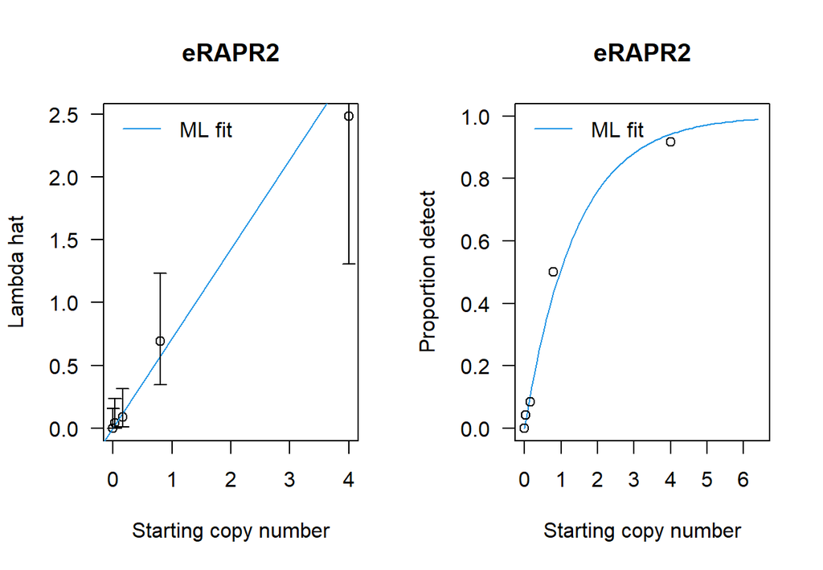

```
##
##
##
##
##  eRAPR2
## Convergence= 0
##       Estimate  Std.Err Z value  Pr(>z)
## alpha 6.47e-08 2.33e-02    0.00       1
## beta  7.13e-01 1.49e-01    4.78 1.8e-06 ***
## ---
## Signif. codes:  0 '***' 0.001 '**' 0.01 '*' 0.05 '.' 0.1 ' ' 1
## LLR test stat= 1.148937 , df=  3 , p-value= 0.7652756
```

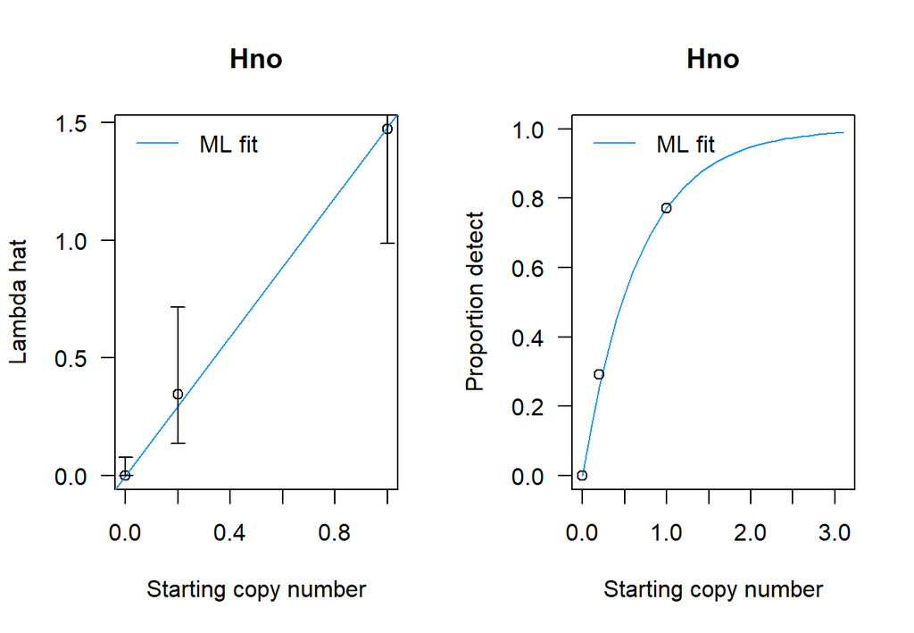

```
##
##
##
##
##  Hno
## Convergence= 0
##       Estimate  Std.Err Z value  Pr(>z)
## alpha 1.15e-09 1.55e-01     0.0       1
## beta  1.48e+00 3.61e-01     4.1 4.2e-05 ***
## ---
## Signif. codes:  0 '***' 0.001 '**' 0.01 '*' 0.05 '.' 0.1 ' ' 1
## LLR test stat= 0.1539404 , df=  1 , p-value= 0.6947979
```

# 8 Estimate predicted Sq given number detects and technical replicates - intercept model (not shown)

# 9 Determine Lc, Ld, Lq - no intercept model

Follows Lavagnini and Magno 2007, Mass Spectrometry Reviews *The notation in the paper was changed from the Lavagnini 2007 paper and is shown in brackets here.*

- Lc (*LOB Limit of blank*) = critical level is the assay signal above which a response is reliably attributed to the presence of analyte
- Ld (*Ld = expected number detects out of NN replicates at concentration LOD*) = signal corresponding to an analyte concentration xd (*=LOD Limit of Detection*) level which may be a priori expected to be recognized
- Lq = quantification limit is a signal with a precision which satisfies an expected value (*=gamma_Q*)

Lc corresponds to a critical response level or a false positive rate, i.e. critical number of detects given NN replicates, above which we would reject the null hypothesis that the concentration/copy number is zero at alpha = alphaLc (*=gamma_{FP}*). It is the critical response level corresponding to the false positive rate of alphaLc. Essentially, the test is positive if the Y~Binomial(m, p) > Lc. The False Positive Rate is P(Y > Lc | S=0).

Ld is computed to correspond to the false negative rate, beta = betaLd (*=gamma_{FN}*) here. It is computed so that the probability of observing a new (unknown concentration) response less than or equal to Lc is less than or equal to betaLd. The probability of observing Lc or less detects if the concentration is xd (*=LOD Limit of Detection*) or more is less than or equal to betaLd. The values of Lc depend on the number of replicates, NN, so xd does as well. Ld is the expected number of detects at values xd and NN replicates. False negative rate Ld computation: P(Y <= Lc | p_xd) <= betaLd, and solve for xd.

Lq is less well defined. The literature suggests using Lq = beta0 + 10 s.e.(beta0), but this uses the normality assumption. Other literature suggests using the “analyte concentration xq (*=LOQ Limit of Quantification*) for which the experimental relative standard deviation of the responses reaches a fixed level (*=gamma_Q*), for example, the level 0.1.” Lavagnini and Magno 2007. I interpret the term “relative standard deviation” to mean the coefficient of variation, CV = sd/mean.

In the exercise below, we use the fits from the ML models to estimate the Lc, Ld and Lq, for various values of NN replicates for a new observation, i.e. a new (unknown concentration) response number of detects.

```
## Too few values for  CID
## Too few values for  NZMS
## Too few values for  SAFO
## Too few values for  Elod-2-NU
## Too few values for  MYPI
## Too few values for  Goby
## Too few values for  SS
```

# 10 Determine Lc, Ld, Lq - intercept model

```
## Too few values for  CID
## Too few values for  NZMS
## Too few values for  SAFO
## Too few values for  Elod-2-NU
## Too few values for  MYPI
## Too few values for  Goby
## Too few values for  SS
```

# 11 Estimates, Lc, Ld, Lq for a given number of technical reps NN[NNi]

Choose the model (intercept versus no intercept) with the best LLR test fit.

```
## Limits for best choice model for N= 8
```

```
##           InterModel alpha  aSE beta  bSE Lc SdLow    Sd   SdUp  SqLow     Sq
## D-loop             0  0.00 0.00 1.13 0.15  0  0.26  0.33   0.45   0.99   1.26
## AC1_CID_1          0  0.00 0.00 0.08 0.01  0  3.65  4.94   7.65  13.80  18.69
## MYPI-6             0  0.00 0.00 0.01 0.00  0 53.32 69.83 101.12 201.79 264.24
## MYPI-6t            0  0.00 0.00 0.39 0.05  0  0.75  0.95   1.30   2.83   3.60
## AC1                0  0.00 0.00 1.64 0.24  0  0.18  0.23   0.32   0.67   0.87
## AC3                0  0.00 0.00 1.59 0.24  0  0.18  0.24   0.33   0.69   0.89
## BH1                0  0.00 0.00 0.77 0.11  0  0.38  0.48   0.67   1.44   1.83
## BH2                0  0.00 0.00 0.68 0.10  0  0.43  0.55   0.75   1.63   2.07
## GCTM10             0  0.00 0.00 1.35 0.20  0  0.22  0.28   0.39   0.82   1.05
## GCTM22             0  0.00 0.00 1.36 0.20  0  0.21  0.28   0.39   0.81   1.04
## GCTM32             0  0.00 0.00 1.28 0.19  0  0.23  0.29   0.41   0.85   1.10
## SC4                0  0.00 0.00 0.90 0.14  0  0.32  0.41   0.59   1.21   1.57
## SC5                0  0.00 0.00 0.98 0.15  0  0.30  0.38   0.54   1.12   1.45
## BHC                0  0.00 0.00 0.22 0.02  0  1.42  1.74   2.23   5.38   6.57
## Dre16s             0  0.00 0.00 0.12 0.01  0  2.68  3.18   3.91  10.15  12.04
## SVC                0  0.00 0.00 0.22 0.02  0  1.42  1.74   2.23   5.38   6.57
## YPC                0  0.00 0.00 0.39 0.05  0  0.77  0.96   1.29   2.92   3.65
## eASMO9             0  0.00 0.00 0.77 0.15  0  0.36  0.49   0.78   1.34   1.85
## eASTR4             0  0.00 0.00 0.48 0.09  0  0.56  0.77   1.24   2.12   2.93
## eFISH1             0  0.00 0.00 0.41 0.08  0  0.65  0.90   1.48   2.46   3.42
## eLIPI1             0  0.00 0.00 0.84 0.17  0  0.32  0.45   0.73   1.22   1.70
## eMIDO1             0  0.00 0.00 0.97 0.20  0  0.28  0.38   0.64   1.04   1.46
## eMISA2             0  0.00 0.00 0.58 0.11  0  0.46  0.64   1.04   1.76   2.43
## eONKI4             1  0.07 0.05 0.69 0.16  2  0.74  1.21   2.41   1.24   1.93
## eRAAU1             0  0.00 0.00 0.46 0.09  0  0.58  0.81   1.33   2.21   3.07
## eRACA2             0  0.00 0.00 0.54 0.11  0  0.50  0.69   1.13   1.88   2.61
## eRALU2             0  0.00 0.00 0.42 0.09  0  0.64  0.89   1.49   2.41   3.38
## eRAPR2             0  0.00 0.00 0.71 0.14  0  0.38  0.52   0.85   1.44   1.98
## Hno                0  0.00 0.00 1.51 0.25  0  0.19  0.25   0.36   0.71   0.94
##             SqUp
## D-loop      1.71
## AC1_CID_1  28.95
## MYPI-6    382.66
## MYPI-6t     4.92
## AC1         1.22
## AC3         1.26
## BH1         2.52
## BH2         2.85
## GCTM10      1.47
## GCTM22      1.47
## GCTM32      1.55
## SC4         2.22
## SC5         2.05
## BHC         8.44
## Dre16s     14.80
## SVC         8.44
## YPC         4.87
## eASMO9      2.96
## eASTR4      4.70
## eFISH1      5.61
## eLIPI1      2.78
## eMIDO1      2.41
## eMISA2      3.92
## eONKI4      3.73
## eRAAU1      5.04
## eRACA2      4.28
## eRALU2      5.65
## eRAPR2      3.21
## Hno         1.38
```

# 12 Tables and Graphs for the manuscript

Include MYPI-6t and eASMO9, eFISH1, eONKI4 in paper.  
Index into uTargets (5, 25, 27, 31)

```
##
##
##              alpha   aSE   beta   bSE   Lc   LODL    LOD    LODU    LOQL     LOQ    LOQU   K.LOD8    K.LOQ
## ----------  ------  ----  -----  ----  ---  -----  -----  ------  ------  ------  ------  -------  -------
## AC1            0.0     0    1.6   0.2    0    0.2    0.2     0.3     0.7     0.9     1.2      0.2     10.0
## AC1_CID_1      0.0     0    0.1   0.0    0    3.6    4.9     7.7    13.8    18.7    29.0      5.6    184.0
## AC3            0.0     0    1.6   0.2    0    0.2    0.2     0.3     0.7     0.9     1.3      0.2      9.0
## BH1            0.0     0    0.8   0.1    0    0.4    0.5     0.7     1.4     1.8     2.5      0.3     32.0
## BH2            0.0     0    0.7   0.1    0    0.4    0.5     0.8     1.6     2.1     2.9      0.2     56.0
## BHC            0.0     0    0.2   0.0    0    1.4    1.7     2.2     5.4     6.6     8.4      1.9     15.9
## D-loop         0.0     0    1.1   0.2    0    0.3    0.3     0.5     1.0     1.3     1.7      0.3      6.0
## Dre16s         0.0     0    0.1   0.0    0    2.7    3.2     3.9    10.1    12.0    14.8      3.4    839.0
## eASMO9         0.0     0    0.8   0.1    0    0.4    0.5     0.8     1.3     1.8     3.0      0.3     50.0
## eASTR4         0.0     0    0.5   0.1    0    0.6    0.8     1.2     2.1     2.9     4.7      0.5    130.0
## eFISH1         0.0     0    0.4   0.1    0    0.7    0.9     1.5     2.5     3.4     5.6      0.6    128.0
## eLIPI1         0.0     0    0.8   0.2    0    0.3    0.4     0.7     1.2     1.7     2.8      0.3     62.0
## eMIDO1         0.0     0    1.0   0.2    0    0.3    0.4     0.6     1.0     1.5     2.4      0.4     49.0
## eMISA2         0.0     0    0.6   0.1    0    0.5    0.6     1.0     1.8     2.4     3.9      0.5    159.0
## eONKI4         0.1     0    0.7   0.2    2    0.7    1.2     2.4     1.2     1.9     3.7      0.2    370.0
## eRAAU1         0.0     0    0.5   0.1    0    0.6    0.8     1.3     2.2     3.1     5.0      0.8     44.0
## eRACA2         0.0     0    0.5   0.1    0    0.5    0.7     1.1     1.9     2.6     4.3      0.6     69.0
## eRALU2         0.0     0    0.4   0.1    0    0.6    0.9     1.5     2.4     3.4     5.6      0.7   4576.0
## eRAPR2         0.0     0    0.7   0.1    0    0.4    0.5     0.8     1.4     2.0     3.2      0.4     39.0
## GCTM10         0.0     0    1.4   0.2    0    0.2    0.3     0.4     0.8     1.0     1.5      0.2     25.0
## GCTM22         0.0     0    1.4   0.2    0    0.2    0.3     0.4     0.8     1.0     1.5      0.2    135.0
## GCTM32         0.0     0    1.3   0.2    0    0.2    0.3     0.4     0.9     1.1     1.6      0.3   7631.0
## Hno            0.0     0    1.5   0.2    0    0.2    0.2     0.4     0.7     0.9     1.4      0.2     11.0
## MYPI-6         0.0     0    0.0   0.0    0   53.3   69.8   101.1   201.8   264.2   382.7     78.0    387.2
## MYPI-6t        0.0     0    0.4   0.1    0    0.7    1.0     1.3     2.8     3.6     4.9      1.0     55.0
## SC4            0.0     0    0.9   0.1    0    0.3    0.4     0.6     1.2     1.6     2.2      0.4     20.0
## SC5            0.0     0    1.0   0.1    0    0.3    0.4     0.5     1.1     1.5     2.1      0.4     13.0
## SVC            0.0     0    0.2   0.0    0    1.4    1.7     2.2     5.4     6.6     8.4      1.9     15.9
## YPC            0.0     0    0.4   0.0    0    0.8    1.0     1.3     2.9     3.6     4.9      1.0     40.0
```

```
##
##
## Table: MYPI-6t
##
##      S   num.detect    n   p.tilde   lambda.tilde
## ------  -----------  ---  --------  -------------
##  0.000            0   24     0.000          0.000
##  0.244            3   24     0.125          0.134
##  0.488            4   24     0.167          0.182
##  0.975            9   24     0.375          0.470
##  1.950            9   24     0.375          0.470
##  3.906           22   24     0.917          2.485
##  7.812           22   24     0.917          2.485
##
##
## Table: eASMO9
##
##      S   num.detect    n   p.tilde   lambda.tilde
## ------  -----------  ---  --------  -------------
##  0.000            0   24     0.000          0.000
##  0.032            0   24     0.000          0.000
##  0.160            6   24     0.250          0.288
##  0.800           11   24     0.458          0.613
##  4.000           22   24     0.917          2.485
##
##
## Table: eFISH1
##
##      S   num.detect    n   p.tilde   lambda.tilde
## ------  -----------  ---  --------  -------------
##  0.000            0   24     0.000          0.000
##  0.032            1   24     0.042          0.043
##  0.160            0   24     0.000          0.000
##  0.800           10   24     0.417          0.539
##  4.000           18   24     0.750          1.386
##
##
## Table: eONKI4
##
##      S   num.detect    n   p.tilde   lambda.tilde
## ------  -----------  ---  --------  -------------
##  0.000            0   24     0.000          0.000
##  0.032            3   24     0.125          0.134
##  0.160            6   24     0.250          0.288
##  0.800           14   24     0.583          0.875
##  4.000           21   24     0.875          2.079
```

```
##
##  MYPI-6t
## Convergence= 0
##      Estimate Std.Err Z value  Pr(>z)
## beta    0.394   0.054    7.29 3.1e-13 ***
## ---
## Signif. codes:  0 '***' 0.001 '**' 0.01 '*' 0.05 '.' 0.1 ' ' 1
## LLR test stat= 6.787625 , df=  6 , p-value= 0.340935
##
##
##  eASMO9
## Convergence= 0
##      Estimate Std.Err Z value  Pr(>z)
## beta    0.767   0.147    5.22 1.8e-07 ***
## ---
## Signif. codes:  0 '***' 0.001 '**' 0.01 '*' 0.05 '.' 0.1 ' ' 1
## LLR test stat= 5.106559 , df=  4 , p-value= 0.2765376
##
##
##  eFISH1
## Convergence= 0
##      Estimate Std.Err Z value  Pr(>z)
## beta   0.4139  0.0823    5.03 4.9e-07 ***
## ---
## Signif. codes:  0 '***' 0.001 '**' 0.01 '*' 0.05 '.' 0.1 ' ' 1
## LLR test stat= 6.63572 , df=  4 , p-value= 0.1564373
##
##
##  eONKI4
## Convergence= 0
##       Estimate Std.Err Z value  Pr(>z)
## alpha   0.0749  0.0486    1.54    0.12
## beta    0.6939  0.1601    4.33 1.5e-05 ***
## ---
## Signif. codes:  0 '***' 0.001 '**' 0.01 '*' 0.05 '.' 0.1 ' ' 1
## LLR test stat= 7.671079 , df=  3 , p-value= 0.05332185
```

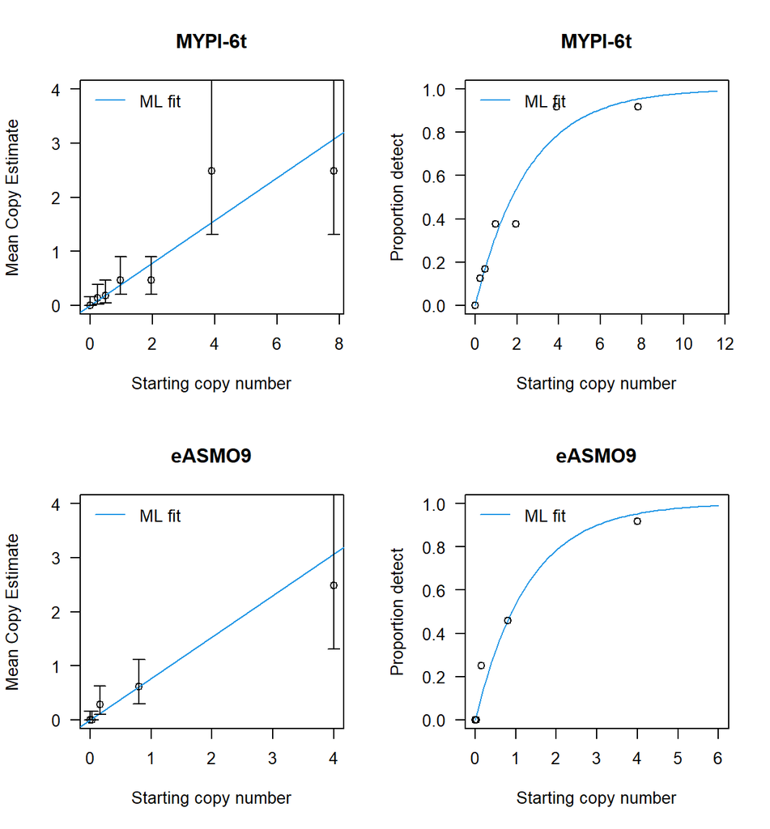

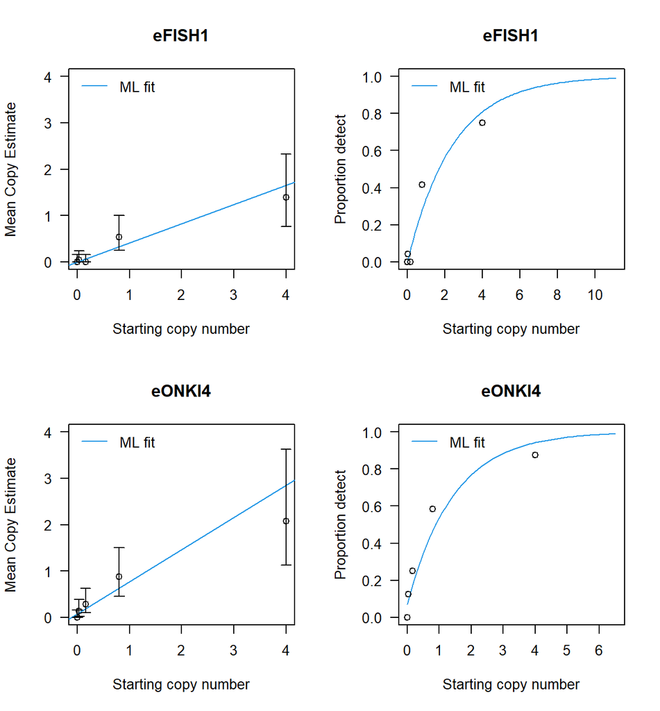

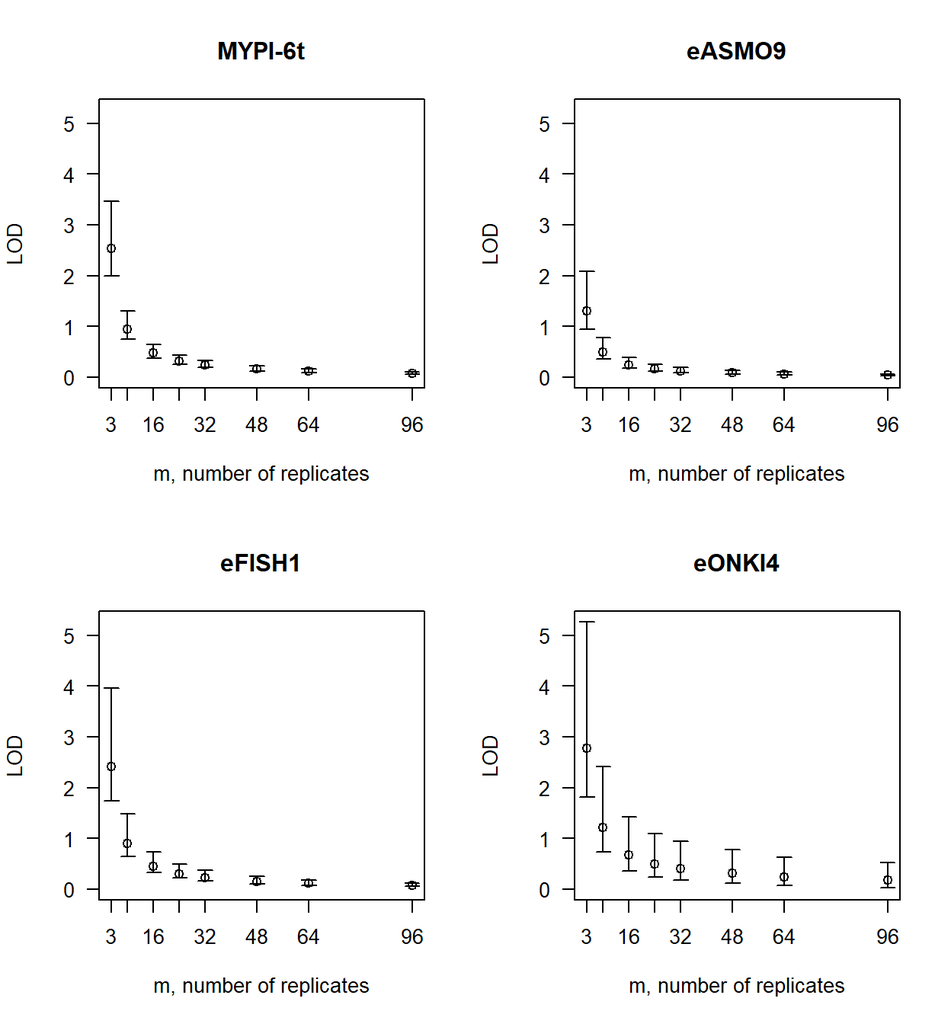

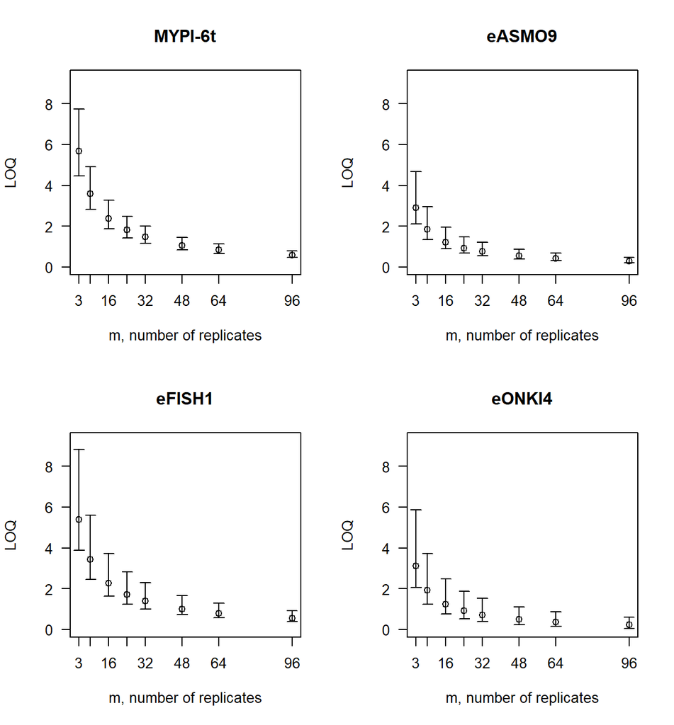

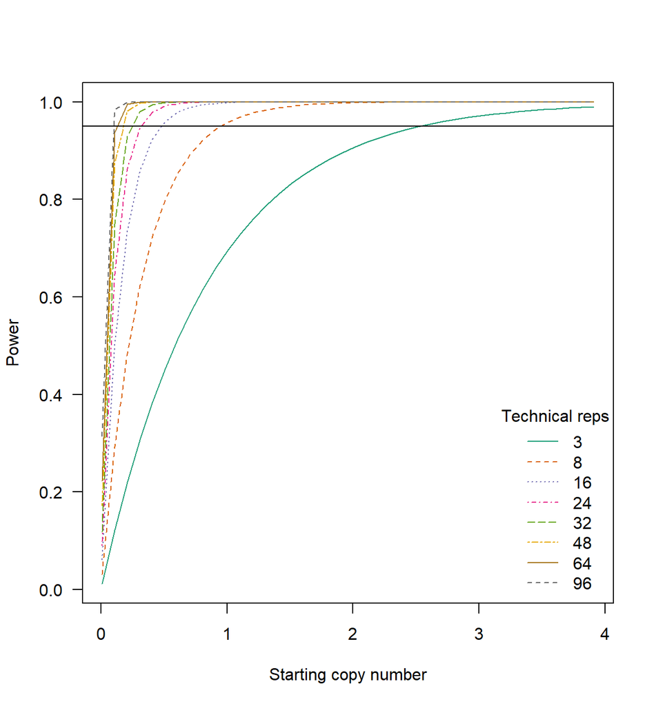